© Bản quyền thuộc về Quantopian Inc.  
© Bản quyền sửa đổi thuộc về AI Cafe¹  
Giấy phép [Creative Commons Attribution 4.0](https://creativecommons.org/licenses/by/4.0/legalcode).  
[Khuyến cáo](https://aicafe.one/khuyen-cao/)

# Integration, Cointegration và Stationarity

by Delaney Granizo-Mackenzie and Maxwell Margenot

Edited by AI Cafe¹

```python
import numpy as np
import pandas as pd

import statsmodels.api as sm
from statsmodels.tsa.stattools import coint, adfuller

import matplotlib.pyplot as plt
```

## Tính Dừng/Không Dừng

Một giả định thường không được kiểm tra trong phân tích chuỗi thời gian là tính dừng của dữ liệu. Dữ liệu được coi là dừng khi các tham số của quá trình sinh dữ liệu không thay đổi theo thời gian. Ví dụ, hãy xem xét hai chuỗi, A và B. Chuỗi A được tạo ra từ một quá trình dừng với các tham số cố định, trong khi chuỗi B được sinh ra với các tham số thay đổi theo thời gian.

```python
def generate_datapoint(params):
    mu = params[0]
    sigma = params[1]
    return np.random.normal(mu, sigma)
```

### Chuỗi A

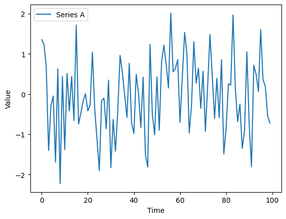

```python
# Set the parameters and the number of datapoints
params = (0, 1)
T = 100

A = pd.Series(index=range(T), dtype='float64')
A.name = 'A'

for t in range(T):
    A[t] = generate_datapoint(params)

plt.plot(A)
plt.xlabel('Time')
plt.ylabel('Value')
plt.legend(['Series A']);
```

### Chuỗi B

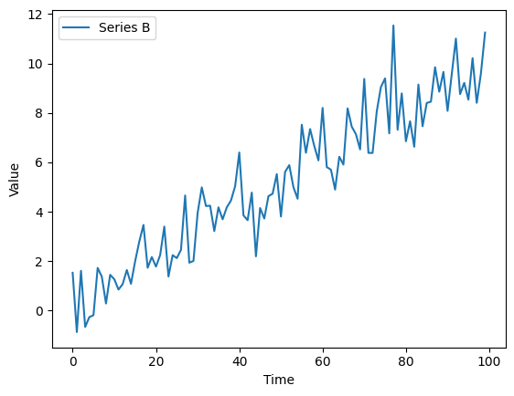

```python
# Set the number of datapoints
T = 100

B = pd.Series(index=range(T), dtype="float64")
B.name = 'B'

for t in range(T):
    # Now the parameters are dependent on time
    # Specifically, the mean of the series changes over time
    params = (t * 0.1, 1)
    B[t] = generate_datapoint(params)

plt.plot(B)
plt.xlabel('Time')
plt.ylabel('Value')
plt.legend(['Series B']);
```

### Tại Sao Tính Không Dừng Là Nguy Hiểm

Nhiều bài kiểm tra thống kê, ở sâu trong các điều kiện giả định của chúng, yêu cầu rằng dữ liệu được kiểm tra phải là dừng. Ngoài ra, nếu bạn sử dụng một cách ngây thơ một số thống kê trên một tập dữ liệu không dừng, bạn sẽ nhận được kết quả không hợp lý. Ví dụ, hãy xem xét việc lấy trung bình qua dữ liệu không dừng $B$ của chúng ta.

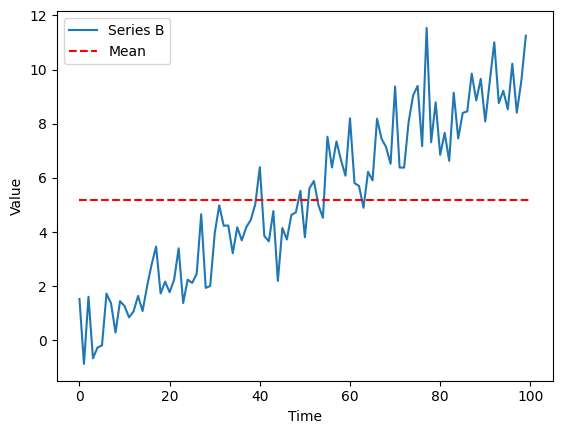

```python
m = np.mean(B)

plt.plot(B)
plt.hlines(m, 0, len(B), linestyles='dashed', colors='r')
plt.xlabel('Time')
plt.ylabel('Value')
plt.legend(['Series B', 'Mean']);
```

Giá trị trung bình được tính toán sẽ cho thấy giá trị trung bình của tất cả các điểm dữ liệu, nhưng sẽ không hữu ích cho bất kỳ dự đoán nào về trạng thái tương lai. Nó trở nên vô nghĩa khi so sánh với bất kỳ thời điểm cụ thể nào, vì đó là một tập hợp các trạng thái khác nhau tại các thời điểm khác nhau được trộn lẫn với nhau. Đây chỉ là một ví dụ đơn giản và rõ ràng về việc tại sao tính không ổn định có thể gây rắc rối cho phân tích, và những vấn đề tinh vi hơn có thể phát sinh trong thực tế.

### Kiểm tra Tính dừng

Bây giờ chúng ta muốn kiểm tra tính dừng bằng cách sử dụng một bài kiểm tra thống kê.

```python
def check_for_stationarity(X, cutoff=0.01):
    # H_0 in adfuller is unit root exists (non-stationary)
    # We must observe significant p-value to convince ourselves that the series is stationary
    pvalue = adfuller(X)[1]
    if pvalue < cutoff:
        print('p-value = ' + str(pvalue) + ' The series ' + X.name +' is likely stationary.')
        return True
    else:
        print('p-value = ' + str(pvalue) + ' The series ' + X.name +' is likely non-stationary.')
        return False
```

```python
check_for_stationarity(A);
check_for_stationarity(B);
```

```
p-value = 5.860216518936539e-17 The series A is likely stationary.
p-value = 0.8754786165991262 The series B is likely non-stationary.
```

Chắc chắn rồi, sự thay đổi trung bình của chuỗi làm cho nó không dừng. Hãy thử một ví dụ có thể tinh vi hơn một chút.

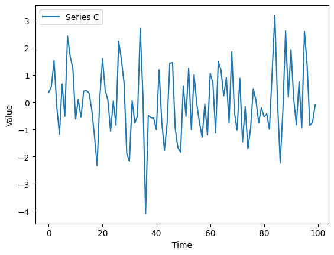

```python
# Set the number of datapoints
T = 100

C = pd.Series(index=range(T), dtype="float64")
C.name = 'C'

for t in range(T):
    # Now the parameters are dependent on time
    # Specifically, the mean of the series changes over time
    params = (np.sin(t), 1)
    C[t] = generate_datapoint(params)

plt.plot(C)
plt.xlabel('Time')
plt.ylabel('Value')
plt.legend(['Series C']);
```

Một chuyển động chu kỳ của trung bình sẽ rất khó để phân biệt với nhiễu ngẫu nhiên. Trong thực tế, trên dữ liệu nhiễu và kích thước mẫu hạn chế, có thể rất khó để xác định liệu một chuỗi có dừng hay không và liệu bất kỳ sự trôi dạt nào là nhiễu ngẫu nhiên hay một phần của xu hướng. Trong từng trường hợp cụ thể, bài kiểm tra có thể phát hiện hoặc không phát hiện các hiệu ứng tinh vi như vậy.

```python
check_for_stationarity(C);
```

```
p-value = 0.0056053788809016306 The series C is likely stationary.
```

## Thứ tự Tích hợp (Integration)

### Đại diện Trung bình động / Định lý Wold

Một khái niệm quan trọng trong phân tích chuỗi thời gian là đại diện trung bình động.

Đại diện này biểu thị bất kỳ chuỗi thời gian nào $Y_t$ như sau:

$$Y_t = \sum_{j=0}^\infty b_j \epsilon_{t-j} + \eta_t$$

- $\epsilon$ là chuỗi 'đổi mới'
- $b_j$ là trọng số trung bình động của chuỗi đổi mới
- $\eta$ là một chuỗi xác định

Điều quan trọng ở đây như sau. $\eta$ là xác định, chẳng hạn như một sóng sine. Do đó, chúng ta có thể mô hình hóa nó một cách hoàn hảo. Quy trình đổi mới là ngẫu nhiên và có mặt để mô phỏng thông tin mới xảy ra theo thời gian. Cụ thể, $\epsilon_t = \hat Y_t - Y_t$ trong đó $\hat Y_t$ là dự đoán tối ưu của $Y_t$ chỉ sử dụng thông tin từ thời gian trước $t$. Nói cách khác, dự đoán tốt nhất mà bạn có thể thực hiện tại thời điểm $t-1$ không thể tính đến sự ngẫu nhiên trong $\epsilon$.

Mỗi $b_j$ chỉ ra mức độ ảnh hưởng của các giá trị trước đó của $\epsilon$ đến $Y_t$.

### Quay lại Thứ tự Tích hợp

Chúng ta sẽ ghi chú thứ tự tích hợp-i là $I(i)$.

Một chuỗi thời gian được cho là $I(0)$ nếu điều kiện sau đây được thỏa mãn trong một đại diện trung bình động. Nói một cách đơn giản, tự tương quan của chuỗi suy giảm đủ nhanh.

$$\sum_{k=0}^\infty |b_k|^2 < \infty$$

Tính chất này hóa ra đúng với tất cả các chuỗi dừng, nhưng tự nó không đủ để giữ cho chuỗi dừng. Điều này có nghĩa là trạng thái dừng suy ra $I(0)$, nhưng $I(0)$ không suy ra trạng thái dừng. Để biết thêm về các thứ tự tích hợp, vui lòng xem các liên kết sau.

- https://en.wikipedia.org/wiki/Order_of_integration
- https://en.wikipedia.org/wiki/Wold%27s_theorem

### Kiểm tra cho $I(0)$

Trong thực tế, việc kiểm tra xem tổng của các tự tương quan có hữu hạn hay không có thể không khả thi. Điều này có thể trong một phép suy diễn toán học, nhưng khi chúng ta có một tập dữ liệu hữu hạn và một số lượng ước lượng tự tương quan hữu hạn, tổng sẽ luôn hữu hạn. Với khó khăn này, các bài kiểm tra cho $I(0)$ dựa vào trạng thái dừng suy ra tính chất. Nếu chúng ta phát hiện rằng một chuỗi là dừng, thì nó cũng phải là $I(0)$.

Hãy xem xét chuỗi A ban đầu của chúng ta (chuỗi dừng). Bởi vì A là chuỗi dừng, chúng ta biết rằng nó cũng là $I(0)$.

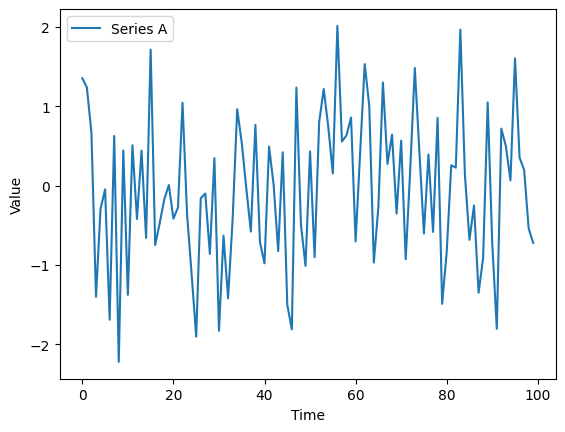

```python
plt.plot(A)
plt.xlabel('Time')
plt.ylabel('Value')
plt.legend(['Series A']);
```

### Xây dựng các bậc tích hợp một cách quy nạp

Nếu ta lấy một chuỗi $I(0)$ và tính tổng tích lũy của nó (tích phân rời rạc), chuỗi mới sẽ là $I(1)$. Lưu ý rằng điều này liên quan đến khái niệm tích phân trong giải tích. Mối quan hệ tương tự cũng áp dụng chung, để có được $I(n)$, ta lấy một chuỗi $I(0)$ và thực hiện việc tính tổng tích lũy lặp lại $n$ lần.

Bây giờ, hãy tạo một chuỗi $I(1)$ bằng cách lấy tổng tích lũy của A.

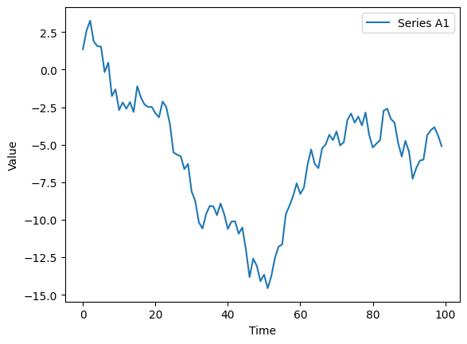

```python
A1 = np.cumsum(A)

plt.plot(A1)
plt.xlabel('Time')
plt.ylabel('Value')
plt.legend(['Series A1']);
```

Bây giờ hãy tạo một $I(2)$ bằng cách tính tổng tích lũy một lần nữa.

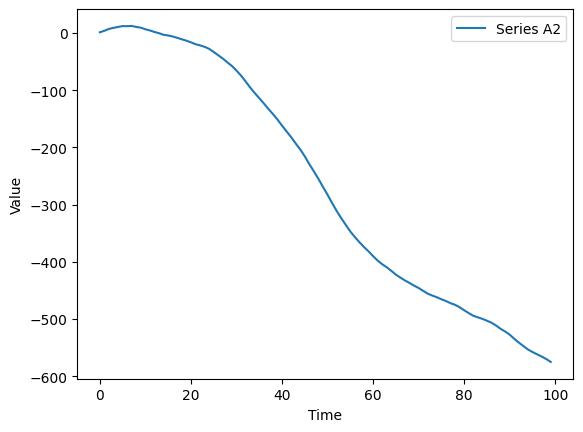

```python
A2 = np.cumsum(A1)

plt.plot(A2)
plt.xlabel('Time')
plt.ylabel('Value')
plt.legend(['Series A2']);
```

### Phân Tích Cấp Độ Tích Hợp

Ngược lại, để tìm cấp độ tích hợp của một chuỗi cho trước, chúng ta thực hiện phép toán ngược của tổng tích lũy, đó là hàm khác biệt $\Delta$ hoặc khác biệt theo từng mục. Cụ thể là

$$(1-L) X_t = X_t - X_{t-1} = \Delta X$$

$$(1-L)^d X_t$$

Trong trường hợp này, $L$ là toán tử độ trễ. Đôi khi cũng được viết là $B$ để chỉ 'lùi lại'. $L$ lấy các phần tử thứ hai đến cuối trong một chuỗi thời gian, và $L^k$ lấy các phần tử thứ k đến cuối. Vì vậy

$$L X_t = X_{t-1}$$

và

$$(1-L) X_t = X_t - X_{t-1}$$

Một chuỗi $Y_t$ được gọi là $I(1)$ nếu $Y_t - Y_{t-1}$ là $I(0)$. Nói cách khác, nếu bạn lấy một chuỗi $I(0)$ và tính tổng tích lũy của nó, bạn sẽ nhận được một chuỗi $I(1)$.

### Điều Cần Nhớ Quan Trọng

Khi tất cả các phép toán đã được thực hiện, hãy nhớ rằng bất kỳ chuỗi nào dừng cũng đều là $I(0)$.

## Dữ liệu thực

Hãy thử nghiệm điều này với một số dữ liệu giá thực tế.

```python
# Cài thư viện lấy dữ liệu miễn phí
!curl -fsSLO https://raw.githubusercontent.com/algo-stocks/data/master/data.py
```

```python
from data import get_prices

start = '2024-01-01'
end = '2025-01-01'

X = get_prices('FPT', start_date=start, end_date=end).FPT
```

```python
check_for_stationarity(X);
```

```
p-value = 0.7766633037232126 The series FPT is likely non-stationary.
```

Hãy cùng xem xét, chắc chắn có những dấu hiệu cảnh báo của một chuỗi không dừng.

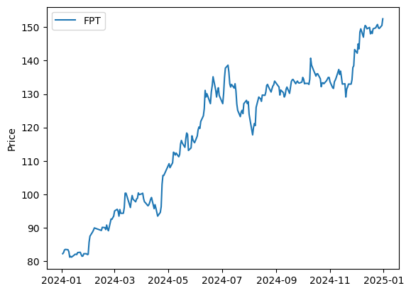

```python
plt.plot(X.index, X.values)
plt.ylabel('Price')
plt.legend([X.name]);
```

Bây giờ chúng ta hãy lấy delta của chuỗi, điều này sẽ cho chúng ta lợi nhuận theo phép cộng. Chúng ta sẽ kiểm tra xem giá trị này có dừng không.

```
p-value = 2.617068536788655e-26 The series FPT Additive Returns is likely stationary.
```

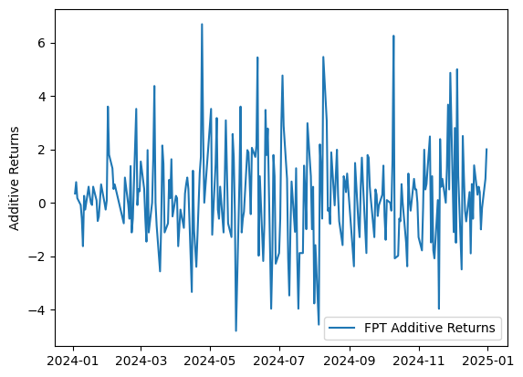

```python
X1 = X.diff()[1:]
X1.name = X.name + ' Additive Returns'
check_for_stationarity(X1)
plt.plot(X1.index, X1.values)
plt.ylabel('Additive Returns')
plt.legend([X1.name]);
```

Có vẻ như lợi nhuận theo phép cộng là ổn định trong năm 2024. Điều này có nghĩa là chúng ta sẽ có khả năng mô hình hóa lợi nhuận tốt hơn nhiều so với giá. Nó cũng có nghĩa là giá đã ở dạng $I(1)$.

Hãy cũng kiểm tra lợi nhuận theo phép nhân.

```
p-value = 6.025943237062237e-26 The series FPT Multiplicative Returns is likely stationary.
```

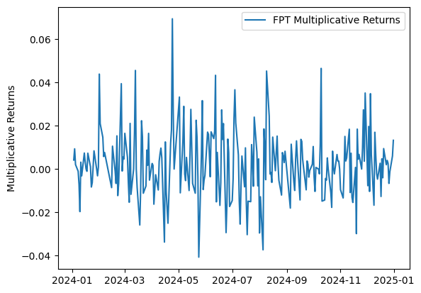

```python
X1 = X.pct_change()[1:]
X1.name = X.name + ' Multiplicative Returns'
check_for_stationarity(X1)
plt.plot(X1.index, X1.values)
plt.ylabel('Multiplicative Returns')
plt.legend([X1.name]);
```

Có vẻ như lợi nhuận theo phép nhân cũng là dừng. Cả delta nhân và delta cộng của một chuỗi đều cung cấp thông tin tương tự nhau, vì vậy không có gì ngạc nhiên khi cả hai đều dừng. Trong thực tế, điều này có thể không phải lúc nào cũng đúng.

### GHI CHÚ QUAN TRỌNG

Như mọi khi, bạn không nên ngây thơ giả định rằng vì một chuỗi thời gian là dừng trong quá khứ thì nó sẽ tiếp tục là dừng trong tương lai. Các thử nghiệm để kiểm tra tính nhất quán của tính dừng như kiểm tra chéo và kiểm tra ngoài mẫu là cần thiết. Điều này đúng với bất kỳ thuộc tính thống kê nào, chúng tôi chỉ nhắc lại ở đây. Lợi tức cũng có thể vào và ra khỏi trạng thái dừng, và có thể là dừng hoặc không dừng tùy thuộc vào khung thời gian và tần suất lấy mẫu.

## Lưu ý: Phân tích Lợi suất

Lý do lợi suất thường được sử dụng trong mô hình hóa tài chính định lượng là vì chúng có tính ổn định cao hơn so với giá cả. Điều này làm cho việc mô hình hóa chúng dễ dàng hơn và việc dự đoán lợi suất trở nên khả thi hơn. Dự đoán giá cả thì khó khăn hơn, vì có nhiều xu hướng do sự tích hợp $I(1)$ của chúng. Ngay cả việc sử dụng mô hình dự đoán lợi suất để dự đoán giá cũng có thể gặp khó khăn, vì bất kỳ sai sót nào trong dự đoán lợi suất sẽ được phóng đại theo thời gian.

## Đồng tích hợp (Cointegration)

Chúng ta đã thảo luận về tính dừng và bậc tích hợp, bây giờ chúng ta có thể nói về đồng tích hợp.

### Định nghĩa: Tổ hợp tuyến tính

Một tổ hợp tuyến tính của các chuỗi thời gian ($X_1$, $X_2$, $\dots$, $X_k$) là một chuỗi thời gian mới $Y$ được xây dựng như sau cho bất kỳ tập hợp nào của các số thực $b_1 \dots b_k$:

$$Y = b_1X_1 + b_2X_2 + \dots + b_kX_k$$

### Định nghĩa chính thức

Định nghĩa chính thức về đồng tích hợp là như sau.

Đối với một tập hợp các chuỗi thời gian ($X_1$, $X_2$, $\dots$, $X_k$), nếu tất cả các chuỗi đều là $I(1)$, và một số tổ hợp tuyến tính của chúng là $I(0)$, chúng ta nói rằng tập hợp các chuỗi thời gian này là đồng tích hợp.

#### Ví dụ

$X_1$, $X_2$, và $X_3$ đều là $I(1)$, và $2X_1 + X_2 + 0X_3 = 2X_1 + X_2$ là $I(0)$. Trong trường hợp này, các chuỗi thời gian là đồng tích hợp.

### Trực giác

Trực giác ở đây là đối với một tổ hợp tuyến tính nào đó của các chuỗi, kết quả thiếu nhiều tự hiệp phương sai và chủ yếu là nhiễu. Điều này rất hữu ích cho các trường hợp như giao dịch cặp, trong đó chúng ta tìm hai tài sản có giá cả đồng tích hợp. Vì tổ hợp tuyến tính của giá cả của chúng $b_1A_1 + b_2A_2$ là nhiễu, chúng ta có thể đặt cược vào mối quan hệ $b_1A_1 + b_2A_2$ sẽ quay về giá trị trung bình và thực hiện các giao dịch theo đó. Xem Bài giảng Giao dịch Cặp để biết thêm thông tin.

### Ví dụ Dữ liệu Mô phỏng

Hãy tạo một số dữ liệu để minh họa điều này.

```python
# Length of series
N = 100

# Generate a stationary random X1
X1 = np.random.normal(0, 1, N)
# Integrate it to make it I(1)
X1 = np.cumsum(X1)
X1 = pd.Series(X1)
X1.name = 'X1'

# Make an X2 that is X1 plus some noise
X2 = X1 + np.random.normal(0, 1, N)
X2.name = 'X2'
```

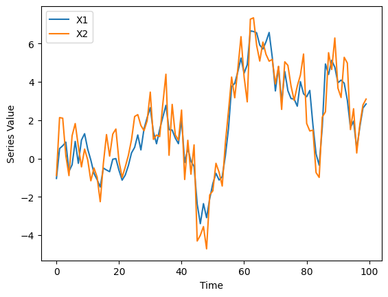

```python
plt.plot(X1)
plt.plot(X2)
plt.xlabel('Time')
plt.ylabel('Series Value')
plt.legend([X1.name, X2.name]);
```

Bởi vì $X_2$ chỉ là một chuỗi $I(1)$ cộng với một số nhiễu tĩnh, nên nó vẫn nên là $I(1)$. Hãy kiểm tra điều này.

```python
Z = X2.diff()[1:]
Z.name = 'Z'

check_for_stationarity(Z);
```

```
p-value = 5.129595313012713e-25 The series Z is likely stationary.
```

Trông có vẻ tốt. Bây giờ để chứng minh sự đồng tích hợp, chúng ta cần tìm một tổ hợp tuyến tính của $X_1$ và $X_2$ là dừng. Chúng ta có thể lấy $X_2 - X_1$. Tất cả những gì còn lại sẽ là nhiễu dừng theo thiết kế. Hãy kiểm tra điều này.

```
p-value = 5.2026703238165325e-15 The series Z is likely stationary.
```

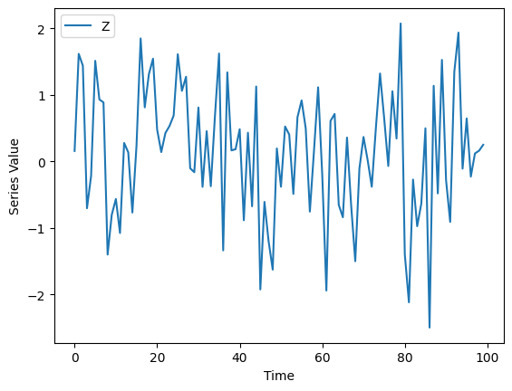

```python
Z = X2 - X1
Z.name = 'Z'

plt.plot(Z)
plt.xlabel('Time')
plt.ylabel('Series Value')
plt.legend(['Z']);

check_for_stationarity(Z);
```

### Kiểm tra đồng tích hợp

Có nhiều cách để kiểm tra đồng tích hợp. Bài viết trên [Wikipedia này](https://en.wikipedia.org/wiki/Cointegration) mô tả một số phương pháp. Nói chung, chúng ta chỉ đang cố gắng tìm các hệ số $b_1, \dots, b_k$ để tạo ra một tổ hợp tuyến tính $I(0)$. Nếu ước lượng tốt nhất cho các hệ số này không vượt qua kiểm tra tính dừng, thì chúng ta bác bỏ giả thuyết rằng tập hợp đó là đồng tích hợp. Điều này sẽ dẫn đến nguy cơ về lỗi loại II (âm tính giả), vì chúng ta sẽ không kiểm tra đầy đủ tính dừng cho tất cả các tổ hợp hệ số. Tuy nhiên, lỗi loại II thường không vấn đề ở đây, vì chúng là an toàn và không dẫn đến việc chúng ta đưa ra bất kỳ dự đoán sai nào.

Trên thực tế, một cách phổ biến để thực hiện điều này cho các cặp chuỗi thời gian là sử dụng hồi quy tuyến tính để ước lượng $\beta$ trong mô hình sau:

$$X_2 = \alpha + \beta X_1 + \epsilon$$

Ý tưởng là nếu hai biến này đồng tích hợp, chúng ta có thể loại bỏ sự phụ thuộc của $X_2$ vào $X_1$, để lại những nhiễu có tính dừng. Tổ hợp $X_2 - \beta X_1 = \alpha + \epsilon$ nên là một chuỗi dừng.

#### Ví dụ Dữ Liệu Thực

Hãy thử trên một số dữ liệu thực. Chúng ta sẽ lấy giá và vẽ biểu đồ trước.

```python
prices = get_prices('VRE', 'VIC', start_date='2024-01-01', end_date='2025-01-01')

X1 = prices['VRE']
X2 = prices['VIC']
```

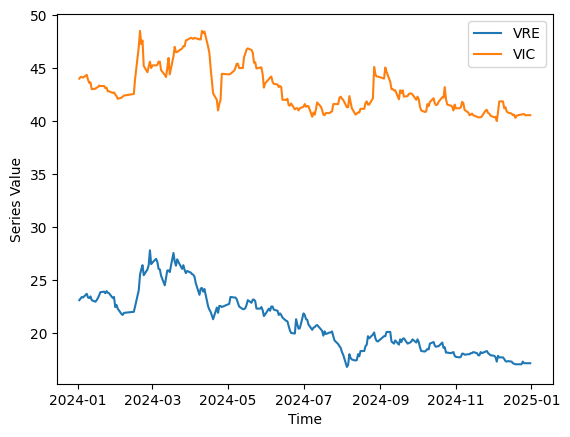

```python
plt.plot(X1.index, X1.values)
plt.plot(X1.index, X2.values)
plt.xlabel('Time')
plt.ylabel('Series Value')
plt.legend([X1.name, X2.name]);
```

Tính toán hệ số $\beta$ bằng hồi quy tuyến tính

```python
X1 = sm.add_constant(X1)
results = sm.OLS(X2, X1).fit()

# Get rid of the constant column
X1 = X1['VRE']

results.params
```

|  | 0 |
| --- | --- |
| const | 29.974491 |
| VRE | 0.620123 |

**dtype:** float64

```
p-value = 0.002097306396556048 The series Z is likely stationary.
```

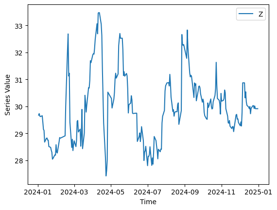

```python
b = results.params['VRE']
Z = X2 - b * X1
Z.name = 'Z'

plt.plot(Z.index, Z.values)
plt.xlabel('Time')
plt.ylabel('Series Value')
plt.legend([Z.name]);

check_for_stationarity(Z);
```

### Đây chỉ là một dự đoán!

Hãy nhớ rằng, giống như bất kỳ điều gì khác, bạn không nên giả định rằng vì một tập hợp tài sản nào đó đã vượt qua bài kiểm tra đồng tích hợp trong quá khứ, chúng sẽ tiếp tục duy trì sự đồng tích hợp. Bạn cần xác minh rằng hành vi nhất quán xảy ra và sử dụng các kỹ thuật xác thực mô hình khác nhau như bạn sẽ làm với bất kỳ mô hình nào.

Một trong những điều quan trọng nhất trong tài chính là thực hiện nhiều lần cược độc lập. Ở đây, một nhà định lượng sẽ tìm nhiều cặp tài sản mà họ giả thuyết là đồng tích hợp và phân bổ đồng đều số tiền của họ giữa chúng trong các lần cược. Điều này chỉ yêu cầu hơn một nửa số cặp tài sản duy trì sự đồng tích hợp để chiến lược hoạt động. Để biết thêm thông tin về giao dịch cặp, hãy xem bài giảng Giao dịch Cặp.

### Thư viện có sẵn

May mắn thay, có một số bài kiểm tra được xây dựng sẵn cho việc kiểm tra tính đồng tích hợp. Hãy tham khảo tài liệu của statsmodel [tại đây](https://www.statsmodels.org/stable/generated/statsmodels.tsa.stattools.coint.html) để biết thêm chi tiết.

```python
from statsmodels.tsa.stattools import coint

coint(X1, X2)
```

```
(np.float64(-3.064657823545388),
 np.float64(0.0956241505950699),
 array([-3.94096428, -3.3607786 , -3.0615268 ]))
```

*Lưu ý: Tài liệu này mang tính chất chia sẻ kiến thức khoa học dữ liệu. Các mã chứng khoán xuất hiện trong tài liệu chỉ mang tính chất minh hoạ, không khuyến nghị đầu tư. Chúng tôi không chịu trách nhiệm trước mọi rủi ro nào do sử dụng tài liệu này.*